# Hacker News Links Analysis

Szymon Lipiński

# Protocol Distribution

The URLs are gathered regardless the field type, we count one URL per object_id. So, if the same URL appears in the same entry in the title and the description, then it’s counted as one. However, if it’s in a story and in a comment to this story, then they are counted as two separate URLs.

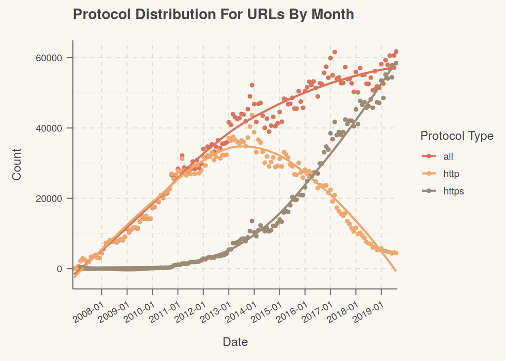

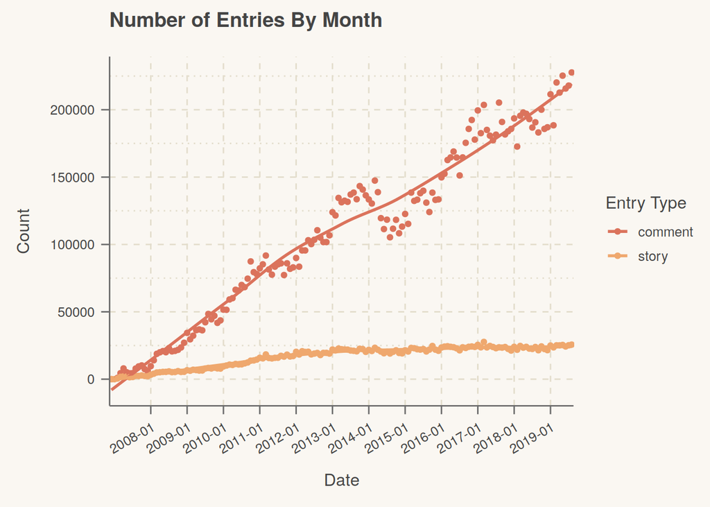

The number of comments for a month is growing almost lineary, while the number of stories is almost the same for the last couple of years.

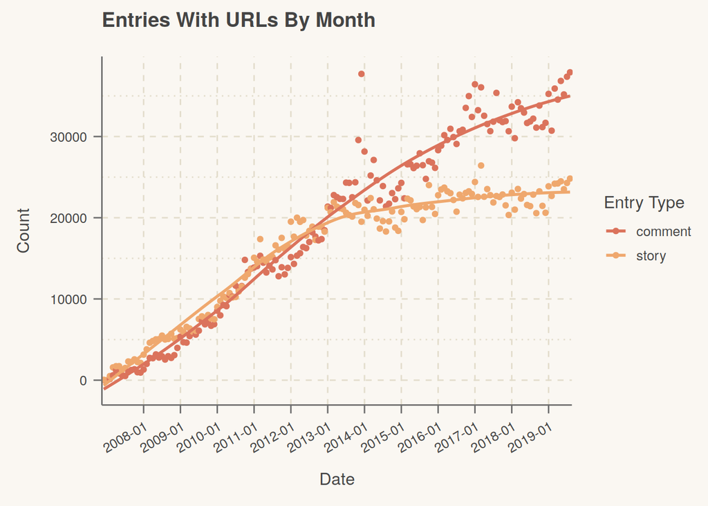

The number of stories and the number of comments with links is also growing, which can be caused by the growth of the entries.

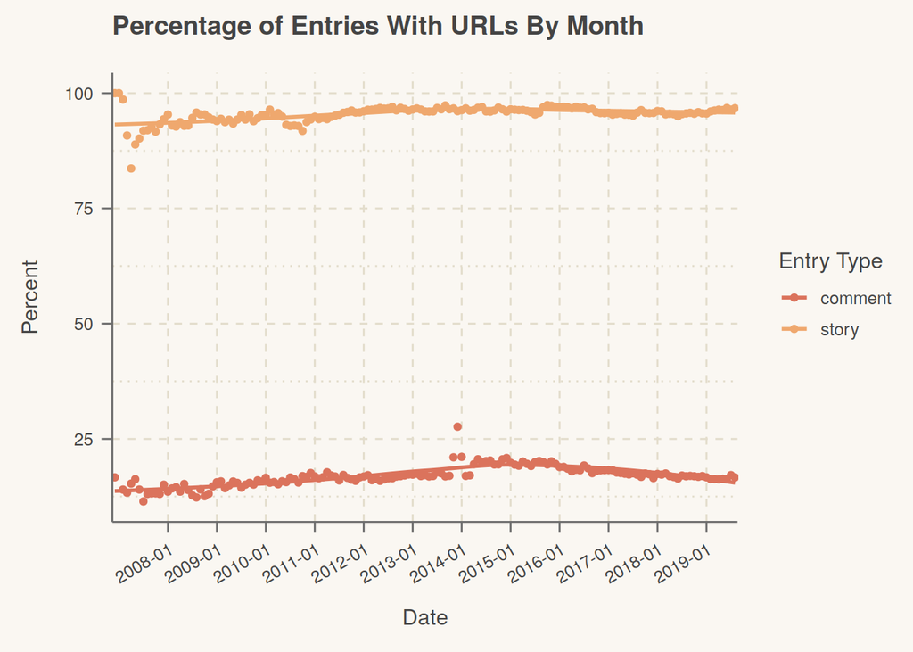

Almost every story has a link and less than 25% of the comments.

The percentage of the stories and the coments with links is almost the same. It looks like the growth of the entries with links, shown on the previous charts, is caused by overall growth of the number of entries.

# The Most Active Domains

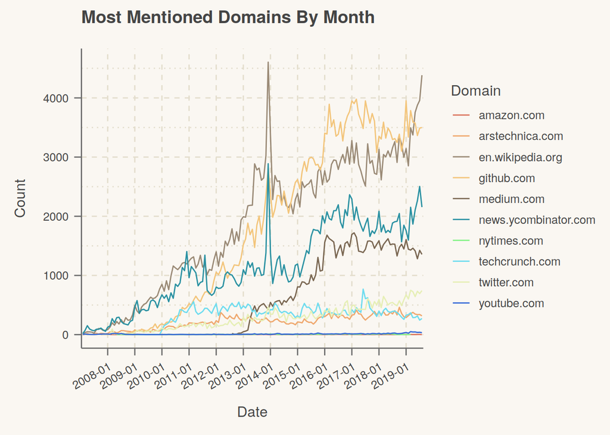

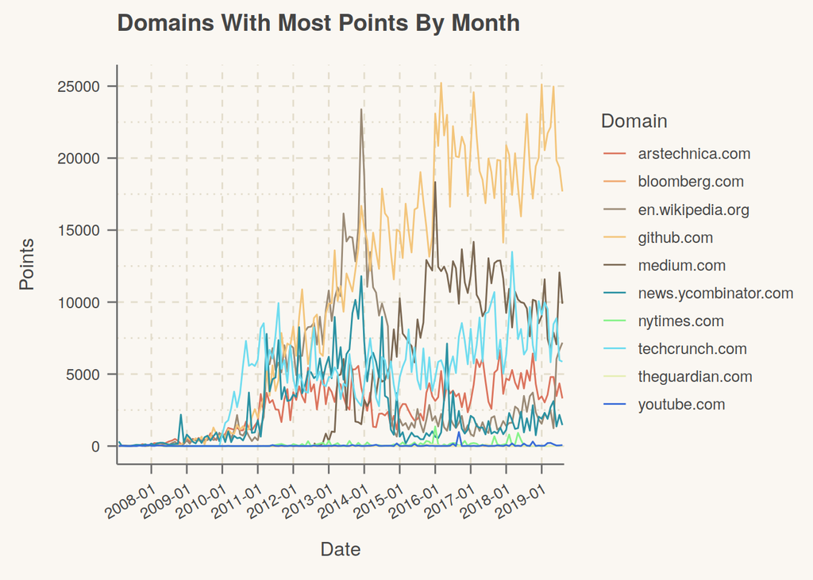

# XKCD :: Comics with The Biggest Number of Points

https://xkcd.com/927/

[figure not shown]

https://xkcd.com/1354/

https://xkcd.com/1838/

[figure not shown]

https://xkcd.com/538/

[figure not shown]

https://xkcd.com/1827/

[figure not shown]

https://xkcd.com/1110/

[figure not shown]

https://xkcd.com/936/

[figure not shown]

https://xkcd.com/1053/

[figure not shown]

https://xkcd.com/radiation/

[figure not shown]

https://xkcd.com/1150/

# Wikipedia :: Pages with The Biggest Number of Points

John McCarthy (computer scientist) John McCarthy (September 4, 1927 – October 24, 2011) was an American computer scientist and cognitive scientist. McCarthy was one of the founders of the discipline of artificial intelligence.[1] He coined the term “artificial intelligence” (AI),[2] developed the Lisp programming language family, significantly influenced the design of the ALGOL programming language, popularized timesharing, and was very influential in the early development of AI. https://en.wikipedia.org/wiki/John_McCarthy_(computer_scientist)

[High-Tech Employee Antitrust Litigation](https://en.wikipedia.org/wiki/High-Tech_Employee_Antitrust_Litigation) High-Tech Employee Antitrust Litigation is a 2010 United States Department of Justice (DOJ) antitrust action and a 2013 civil class action against several Silicon Valley companies for alleged “no cold call” agreements which restrained the recruitment of high-tech employees. https://en.wikipedia.org/wiki/High-Tech_Employee_Antitrust_Litigation

[Timeline of the far future](https://en.wikipedia.org/wiki/Timeline_of_the_far_future) While the future can never be predicted with absolute certainty,[1] present understanding in various scientific fields allows for the prediction of some far-future events, if only in the broadest outline. These fields include astrophysics, which has revealed how planets and stars form, interact, and die; particle physics, which has revealed how matter behaves at the smallest scales; evolutionary biology, which predicts how life will evolve over time; and plate tectonics, which shows how continents shift over millennia. https://en.wikipedia.org/wiki/Timeline_of_the_far_future

[Wikipedia:Wikipedia Signpost/2017-02-27/Op-ed](https://en.wikipedia.org/wiki/Wikipedia:Wikipedia_Signpost/2017-02-27/Op-ed) In biology, the hallmarks of an aggressive cancer include limitless and exponential multiplication of ordinarily beneficial cells, even when the body signals that further multiplication is no longer needed. The Wikipedia page on the wheat and chessboard problem explains that nothing can keep growing exponentially forever. In biology, the unwanted growth usually terminates with the death of the host. Exponential spending increases can often lead to the same undesirable result in organizations. https://en.wikipedia.org/wiki/Wikipedia:Wikipedia_Signpost/2017-02-27/Op-ed

[Great Molasses Flood](https://en.wikipedia.org/wiki/Great_Molasses_Flood) The Great Molasses Flood, also known as the Boston Molasses Disaster or the Great Boston Molasses Flood, and sometimes referred to locally as the Boston Molassacre,[1][2] occurred on January 15, 1919, in the North End neighborhood of Boston, Massachusetts. A large storage tank burst, filled with 2,300,000 US gal (8,700 m3; 8,706,447 liters)[3] (ca 12,000 tons; 10,886 metric tons; 24,000,000 lbs)[4] of molasses, and a wave of molasses rushed through the streets at an estimated 35 mph (56 km/h), killing 21 and injuring 150.[5] The event entered local folklore and residents claimed for decades afterwards that the area still smelled of molasses on hot summer days.[6][5] https://en.wikipedia.org/wiki/Great_Molasses_Flood

[User talk:Jimbo Wales](https://en.wikipedia.org/wiki/User_talk:Jimbo_Wales) Congratulations, Jimbo Wales! Despite your request for donations by the end of June, you have refunded all donations from a small donor. I am glad that Wikipedia is so successful. 84.120.0.236 (talk) 14:11, 5 August 2019 (UTC) https://en.wikipedia.org/wiki/User_talk:Jimbo_Wales

Hy Hy (alternately, Hylang) is a programming language, a dialect of the language Lisp designed to interact with the language Python by translating expressions into Python’s abstract syntax tree (AST). Hy was introduced at Python Conference (PyCon) 2013 by Paul Tagliamonte.[1] https://en.wikipedia.org/wiki/Hy

[Potato paradox](https://en.wikipedia.org/wiki/Potato_paradox) The potato paradox is a mathematical calculation that has a counter-intuitive result. The so-called paradox involves dehydrating potatoes by a seemingly minuscule amount, and then calculating a change in mass which is larger than expected. https://en.wikipedia.org/wiki/Potato_paradox

[Zero rupee note](https://en.wikipedia.org/wiki/Zero_rupee_note) A zero-rupee note is a banknote imitation issued in India as a means of helping to fight systemic political corruption. The notes are “paid” in protest by angry citizens to government functionaries who solicit bribes in return for services which are supposed to be free. Zero rupee notes, which are made to resemble the regular 50 rupee banknote of India, are the creation of a non-governmental organization known as 5th Pillar which has, since their inception in 2007, distributed over 2.5 million notes as of August 2014. The notes remain in current use and thousands of notes are distributed every month. https://en.wikipedia.org/wiki/Zero_rupee_note

[Room 641A](https://en.wikipedia.org/wiki/Room_641A) Coordinates: 37°47′07″N 122°23′48″W / 37.78528°N 122.39667°W / 37.78528; -122.39667 https://en.wikipedia.org/wiki/Room_641A

# Arstechnica :: Pages with The Biggest Number of Points

[SpaceX plans worldwide satellite Internet with low latency, gigabit speed](https://arstechnica.com/information-technology/2016/11/spacex-plans-worldwide-satellite-internet-with-low-latency-gigabit-speed) SpaceX has detailed ambitious plans to bring fast Internet access to the entire world with a new satellite system that offers greater speeds and lower latency than existing satellite networks. https://arstechnica.com/information-technology/2016/11/spacex-plans-worldwide-satellite-internet-with-low-latency-gigabit-speed

[Xamarin now free in Visual Studio](https://arstechnica.com/information-technology/2016/03/xamarin-now-free-in-visual-studio) SAN FRANCISCO—Microsoft bought Xamarin, the popular C#-and-.NET-on-iOS-and-Android, last month. At its Build developer conference today, the company announced the first big step for its new acquisition: Xamarin is now included in every Visual Studio version. https://arstechnica.com/information-technology/2016/03/xamarin-now-free-in-visual-studio

[How “omnipotent” hackers tied to NSA hid for 14 years—and were found at last](https://arstechnica.com/security/2015/02/how-omnipotent-hackers-tied-to-the-nsa-hid-for-14-years-and-were-found-at-last) CANCUN, Mexico — In 2009, one or more prestigious researchers received a CD by mail that contained pictures and other materials from a recent scientific conference they attended in Houston. The scientists didn’t know it then, but the disc also delivered a malicious payload developed by a highly advanced hacking operation that had been active since at least 2001. The CD, it seems, was tampered with on its way through the mail. https://arstechnica.com/security/2015/02/how-omnipotent-hackers-tied-to-the-nsa-hid-for-14-years-and-were-found-at-last

[Facebook scraped call, text message data for years from Android phones [Updated]](https://arstechnica.com/information-technology/2018/03/facebook-scraped-call-text-message-data-for-years-from-android-phones) [Update, March 25, 2018, 20:24 Eastern Time]: Facebook has responded to this and other reports regarding the collection of call and SMS data with a blog post that denies Facebook collected call data surreptitiously. The company also writes that it never sells the data and that users are in control of the data uploaded to Facebook. This “fact check” contradicts several details Ars found in analysis of Facebook data downloads and testimony from users who provided the data. More on the Facebook response is appended to the end of the original article below. https://arstechnica.com/information-technology/2018/03/facebook-scraped-call-text-message-data-for-years-from-android-phones

[Microsoft and GitHub team up to take Git virtual file system to macOS, Linux](https://arstechnica.com/gadgets/2017/11/microsoft-and-github-team-up-to-take-git-virtual-file-system-to-macos-linux) One of the more surprising stories of the past year was Microsoft’s announcement that it was going to use the Git version control system for Windows development. Microsoft had to modify Git to handle the demands of Windows development but said that it wanted to get these modifications accepted upstream and integrated into the standard Git client. https://arstechnica.com/gadgets/2017/11/microsoft-and-github-team-up-to-take-git-virtual-file-system-to-macos-linux

[Sorry, Comcast: Voters say “yes” to city-run broadband in Colorado](https://arstechnica.com/tech-policy/2017/11/voters-reject-cable-lobby-misinformation-campaign-against-muni-broadband) Voters in Fort Collins, Colorado, yesterday approved a ballot question that authorizes the city to build a broadband network, rejecting a cable and telecom industry campaign against the initiative. https://arstechnica.com/tech-policy/2017/11/voters-reject-cable-lobby-misinformation-campaign-against-muni-broadband

[Google’s constant product shutdowns are damaging its brand](https://arstechnica.com/gadgets/2019/04/googles-constant-product-shutdowns-are-damaging-its-brand) It’s only April, and 2019 has already been an absolutely brutal year for Google’s product portfolio. The Chromecast Audio was discontinued January 11. YouTube annotations were removed and deleted January 15. Google Fiber packed up and left a Fiber city on February 8. Android Things dropped IoT support on February 13. Google’s laptop and tablet division was reportedly slashed on March 12. Google Allo shut down on March 13. The “Spotlight Stories” VR studio closed its doors on March 14. The goo.gl URL shortener was cut off from new users on March 30. Gmail’s IFTTT support stopped working March 31. https://arstechnica.com/gadgets/2019/04/googles-constant-product-shutdowns-are-damaging-its-brand

[Patent war goes nuclear: Microsoft, Apple-owned “Rockstar” sues Google](https://arstechnica.com/tech-policy/2013/10/patent-war-goes-nuclear-microsoft-apple-owned-rockstar-sues-google) Canada-based telecom Nortel went bankrupt in 2009 and sold its biggest asset—a portfolio of more than 6,000 patents covering 4G wireless innovations and a range of technologies—at an auction in 2011. https://arstechnica.com/tech-policy/2013/10/patent-war-goes-nuclear-microsoft-apple-owned-rockstar-sues-google

[After 37 years, Voyager 1 has fired up its trajectory thrusters](https://arstechnica.com/science/2017/12/after-37-years-voyager-has-fired-up-its-trajectory-thrusters) At present, the Voyager 1 spacecraft is 21 billion kilometers from Earth, or about 141 times the distance between the Earth and Sun. It has, in fact, moved beyond our Solar System into interstellar space. However, we can still communicate with Voyager across that distance. https://arstechnica.com/science/2017/12/after-37-years-voyager-has-fired-up-its-trajectory-thrusters

[Mickey Mouse will be public domain soon—here’s what that means](https://arstechnica.com/tech-policy/2019/01/a-whole-years-worth-of-works-just-fell-into-the-public-domain) As the ball dropped over Times Square last night, all copyrighted works published in 1923 fell into the public domain (with a few exceptions). Everyone now has the right to republish them or adapt them for use in new works. https://arstechnica.com/tech-policy/2019/01/a-whole-years-worth-of-works-just-fell-into-the-public-domain

# Github :: Pages with The Biggest Number of Points

https://github.com/minimaxir/big-list-of-naughty-strings

https://github.com/jmdugan/blocklists/blob/master/corporations/facebook/all

https://github.com/Eloston/ungoogled-chromium

https://github.com/dear-github/dear-github

https://github.com/docker/docker.github.io/issues/6910

https://github.com/blog/2164-introducing-unlimited-private-repositories

https://github.com/kubernetes/kubernetes/blob/ec2e767e59395376fa191d7c56a74f53936b7653/pkg/controller/volume/persistentvolume/pv_controller.go

https://github.com/shadowsocks/shadowsocks-iOS/issues/124

https://github.com/mxgmn/WaveFunctionCollapse

https://github.com/open-guides/og-aws.git

# Twitter :: Twits and Accounts with The Biggest Number of Points

> Dear [@AppleSupport](https://twitter.com/AppleSupport?ref_src=twsrc%5Etfw), we noticed a *HUGE* security issue at MacOS High Sierra. Anyone can login as “root” with empty password after clicking on login button several times. Are you aware of it [@Apple](https://twitter.com/Apple?ref_src=twsrc%5Etfw)?

> — Lemi Orhan Ergin (@lemiorhan) [November 28, 2017](https://twitter.com/lemiorhan/status/935578694541770752?ref_src=twsrc%5Etfw)

https://twitter.com/lemiorhan/status/935578694541770752

> “Clear all Cookies except Google Cookies”, thanks Chrome. /cc [@matthew_d_green](https://twitter.com/matthew_d_green?ref_src=twsrc%5Etfw) [pic.twitter.com/tR0UJjtPFL](https://t.co/tR0UJjtPFL)

> — Christoph Tavan (@ctavan) [September 24, 2018](https://twitter.com/ctavan/status/1044282084020441088?ref_src=twsrc%5Etfw)

https://twitter.com/ctavan/status/1044282084020441088

> It is with great sadness that I share news of Joe Armstrong's passing away earlier today. Whilst he may no longer be with us, his work has laid the foundation which will be used by generations to come. RIP [@joeerl](https://twitter.com/joeerl?ref_src=twsrc%5Etfw), thank you for inspiring us all.

> — Francesco Cesarini (@FrancescoC) [April 20, 2019](https://twitter.com/FrancescoC/status/1119596234166218754?ref_src=twsrc%5Etfw)

https://twitter.com/FrancescoC/status/1119596234166218754

> Great success: Your protests have worked! The European Parliament has sent the copyright law back to the drawing board. All MEPs will get to vote on [#uploadfilters](https://twitter.com/hashtag/uploadfilters?src=hash&ref_src=twsrc%5Etfw) and the [#linktax](https://twitter.com/hashtag/linktax?src=hash&ref_src=twsrc%5Etfw) September 10–13. Now let's keep up the pressure to make sure we [#SaveYourInternet](https://twitter.com/hashtag/SaveYourInternet?src=hash&ref_src=twsrc%5Etfw)! [pic.twitter.com/VwqAgH0Xs5](https://t.co/VwqAgH0Xs5)

> — Julia Reda (@Senficon) [July 5, 2018](https://twitter.com/Senficon/status/1014814460488413185?ref_src=twsrc%5Etfw)

https://twitter.com/Senficon/status/1014814460488413185

> 🚨 GOOGLE'S USE OF THE DECLARING CODE AND SSO OF APIS IS FAIR USE 🚨

> — sarah jeong (@sarahjeong) [May 26, 2016](https://twitter.com/sarahjeong/status/735924335412543488?ref_src=twsrc%5Etfw)

https://twitter.com/sarahjeong/status/735924335412543488

> A crashed advertisement reveals the code of the facial recognition system used by a pizza shop in Oslo… [pic.twitter.com/4VJ64j0o1a](https://t.co/4VJ64j0o1a)

> — Lee Gamble (@GambleLee) [May 10, 2017](https://twitter.com/GambleLee/status/862307447276544000?ref_src=twsrc%5Etfw)

https://twitter.com/GambleLee/status/862307447276544000

> We're sending humans to Mars! Watch our [#JourneytoMars](https://twitter.com/hashtag/JourneytoMars?src=hash&ref_src=twsrc%5Etfw) briefing live today at 12pm ET: http://t.co/6XtjOi1yJo [#Orion](https://twitter.com/hashtag/Orion?src=hash&ref_src=twsrc%5Etfw) [pic.twitter.com/wrf89sn35A](http://t.co/wrf89sn35A)

> — NASA (@NASA) [December 2, 2014](https://twitter.com/NASA/status/539814651404754944?ref_src=twsrc%5Etfw)

https://twitter.com/NASA/status/539814651404754944

[Tweets by DustinKirkland](https://twitter.com/DustinKirkland?ref_src=twsrc%5Etfw) https://twitter.com/dustinkirkland

> I'm choosing euthanasia etd 1pm.  
> I have no last words.

> — Pieter Hintjens (@hintjens) [October 4, 2016](https://twitter.com/hintjens/status/783254242052206592?ref_src=twsrc%5Etfw)

https://twitter.com/hintjens/status/783254242052206592

> We made a video about launching fireworks over Wi-Fi for the 4th of July only to find out [@YouTube](https://twitter.com/YouTube?ref_src=twsrc%5Etfw) gave us a strike because we teach about hacking, so we can't upload it.  
> YouTube now bans: “Instructional hacking and phishing: Showing users how to bypass secure computer systems”

> — Kody (@KodyKinzie) [July 2, 2019](https://twitter.com/KodyKinzie/status/1146196570083192832?ref_src=twsrc%5Etfw)

https://twitter.com/KodyKinzie/status/1146196570083192832

# About Author

Made by Szymon Lipiński.

Published at https://www.simononsoftware.com/

You can contact me e.g. at https://twitter.com/szymon_lipinski